# 水3 調査実習 第3回 2変数の関係: 散布図と相関

#### Datasaurus

```r
datasaurus_dozen %>%
  group_by(dataset) %>%
  summarize(
    mean_x = mean(x),
    mean_y = mean(y),
    sd_x = sd(x),
    sd_y = sd(y),
    cor_xy  = cor(x, y)) # 記述統計量はどれも似ている。
```

| dataset | mean_x | mean_y | sd_x | sd_y | cor_xy |
| --- | --- | --- | --- | --- | --- |
| away | 54.26610 | 47.83472 | 16.76982 | 26.93974 | -0.06412835 |
| bullseye | 54.26873 | 47.83082 | 16.76924 | 26.93573 | -0.06858639 |
| circle | 54.26732 | 47.83772 | 16.76001 | 26.93004 | -0.06834336 |
| dino | 54.26327 | 47.83225 | 16.76514 | 26.93540 | -0.06447185 |
| dots | 54.26030 | 47.83983 | 16.76774 | 26.93019 | -0.06034144 |
| h_lines | 54.26144 | 47.83025 | 16.76590 | 26.93988 | -0.06171484 |
| high_lines | 54.26881 | 47.83545 | 16.76670 | 26.94000 | -0.06850422 |
| slant_down | 54.26785 | 47.83590 | 16.76676 | 26.93610 | -0.06897974 |
| slant_up | 54.26588 | 47.83150 | 16.76885 | 26.93861 | -0.06860921 |
| star | 54.26734 | 47.83955 | 16.76896 | 26.93027 | -0.06296110 |

[output cut: 3 more lines]

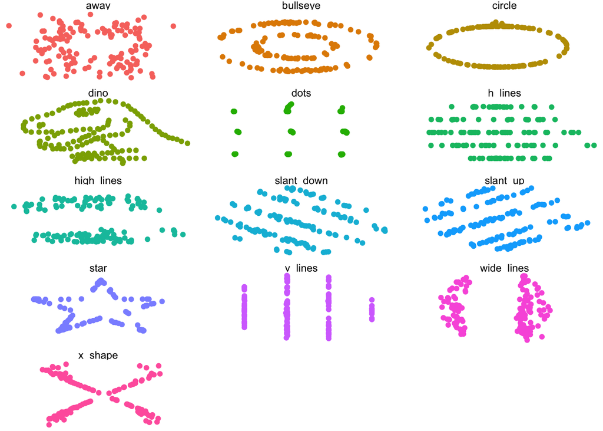

```r
ggplot(datasaurus_dozen, aes(x = x, y = y, colour = dataset)) +
  geom_point() +
  theme_void() +
  theme(legend.position = "none") +
  facet_wrap( ~ dataset, ncol = 3)
```

## 相関係数の検定

### ピアソン相関係数のt検定

```r
#### t-test
cor.test(kwsk$age, kwsk$spouse.age, method = "pearson")
```

```
##
##  Pearson's product-moment correlation
##
## data:  kwsk$age and kwsk$spouse.age
## t = 126.76, df = 1638, p-value < 2.2e-16
## alternative hypothesis: true correlation is not equal to 0
## 95 percent confidence interval:
##  0.9479312 0.9569056
## sample estimates:
##       cor
## 0.9526253
```

```r
#### 帰無仮説（H0): rho = 0である（2つの変数の母相間はゼロである）。
#### 対立仮説（H1): rho = 0ではない（2つの変数は母相間はゼロではない）。
```

### 相関行列とt検定

```r
#### correlation matrix
kwsk %>% select(., age, spouse.age, income) %>%
  cor(., method = "pearson", use = "pairwise.complete.obs") %>%
  round(., 5)
```

```
##                 age spouse.age   income
## age         1.00000    0.95263 -0.13510
## spouse.age  0.95263    1.00000 -0.16565
## income     -0.13510   -0.16565  1.00000
```

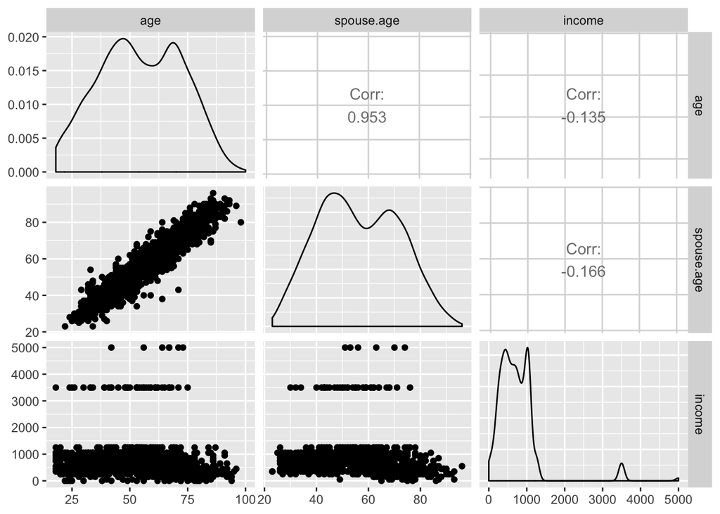

```r
kwsk %>% select(., age, spouse.age, income) %>%
  ggpairs()
```

```r
kwsk %>% select(., age, spouse.age, income) %>%
  as.matrix() %>% rcorr(., type = "pearson")
```

```
##              age spouse.age income
## age         1.00       0.95  -0.14
## spouse.age  0.95       1.00  -0.17
## income     -0.14      -0.17   1.00
##
## n
##             age spouse.age income
## age        2424       1640   1710
## spouse.age 1640       1655   1265
## income     1710       1265   1725
##
## P
##            age spouse.age income
## age             0          0
## spouse.age  0              0
## income      0   0
```

## その他の相関係数

### Kendall’s Tau

```r
cor(kwsk$q14_child, kwsk$q14_jobless, method = "kendall", use = "pairwise.complete.obs")
```

```
## [1] 0.2118863
```

```r
cor.test(kwsk$q14_child, kwsk$q14_jobless, method = "kendall")
```

```
##
##  Kendall's rank correlation tau
##
## data:  kwsk$q14_child and kwsk$q14_jobless
## z = 11.329, p-value < 2.2e-16
## alternative hypothesis: true tau is not equal to 0
## sample estimates:
##       tau
## 0.2118863
```

`factor`型変数は`mutate`と`as.numeric()`で数値型に戻します。

```r
kwsk %>% select(., age, income, edu.fct, q14_sum) %>%
  mutate(edu.fct = as.numeric(edu.fct)) %>%
  cor(., method = "kendall", use = "pairwise.complete.obs") %>%
  round(., 5)
```

```
##              age   income  edu.fct  q14_sum
## age      1.00000 -0.18622 -0.30270  0.04731
## income  -0.18622  1.00000  0.26833 -0.06684
## edu.fct -0.30270  0.26833  1.00000 -0.01752
## q14_sum  0.04731 -0.06684 -0.01752  1.00000
```

### Spearman’s rho

```r
cor(kwsk$q14_jobless, kwsk$q14_inequ, method = "spearman", use = "pairwise.complete.obs")
```

```
## [1] 0.4685975
```

```r
cor.test(kwsk$q14_jobless, kwsk$q14_inequ, method = "spearman", use = "pairwise.complete.obs")
```

```
##
##  Spearman's rank correlation rho
##
## data:  kwsk$q14_jobless and kwsk$q14_inequ
## S = 1100241203, p-value < 2.2e-16
## alternative hypothesis: true rho is not equal to 0
## sample estimates:
##       rho
## 0.4685975
```

```r
kwsk %>% select(., age, income, edu.fct, q14_sum) %>%
  mutate(edu.fct = as.numeric(edu.fct)) %>%
  cor(., method = "spearman", use = "complete.obs") %>%
  round(., 5)
```

```
##              age   income  edu.fct  q14_sum
## age      1.00000 -0.26200 -0.33668  0.04463
## income  -0.26200  1.00000  0.32437 -0.09571
## edu.fct -0.33668  0.32437  1.00000 -0.03239
## q14_sum  0.04463 -0.09571 -0.03239  1.00000
```

## 課題

1. データから自分が興味を持つ変数を2つから5つほど選び（それより多くなっても構わない）、適切な前処理（欠損値の処理、リコード、カテゴリー化など）をする。その変数の特性（すなわち、その変数が何をどのように測定したものであるか、カテゴリカルか量的か、順序尺度か比率尺度かなど）について、各変数ごとに短い説明を付ける。
   1. 記述統計（平均、分散、最大値、最小値）をつける。
2. その変数の間に相関が存在するか、存在するならばそれはどのような関係によるものかを想像し、簡単な理論仮説・作業仮説を作る。
3. 選択した変数の散布図を作り、共分散・ピアソン相関係数（またはKendall’s tau や Spearman’s rho）を求め、求めたグラフ・相関係数の解釈を短く述べること。相関係数には検定結果（p-value）をつける。散布図に回帰直線や、なんらかの近似線を描いても良い。
   1. 必要だと判断した場合は散布図ではなく別のタイプのグラフを描いたり、相関を示すための別の指標を用いたりしても構わない。ただし、その場合は適切な説明を付け加える。
4. 3で得られた結果と2で想像して立てた仮説の関係を短く考察する。求めた相関係数は実際のデータに見られる関係を適切に表しているか。それらの変数の間には本当に相関があったと言えるか。第3要因や偶然による疑似相関ではないか。もしそうならば、考慮に入れるべき（統制すべき）第3要因としては何があり得るか。

締め切り：5月31日23時59分

提出場所：ITC-LMS

形式上の注意：

1. 名前と学籍番号をつける。
2. すべての表・図には適切なタイトルをつける。
3. .doc, .docx, または .pdf 形式で提出する。
4. 自分が用いたコードを添付すること。